# Coronavirus R Package

Dr. Sulove Koirala

7/21/2020

## Introduction

We will be analyzing COVID-19 statistics using the R package, “coronavirus”. The package provides the latest data by scrapping the data from Johns Hopkins University Center for Systems Science and Engineering (JHU-CCSE) Coronavirus repository. The code can be refreshed to obtain the latest information, provided that you installed the required packages. For any kind of collaboration or help reach me at sulovekoirala@gmail.com

## Installation of the coronavirus package

install.packages(“devtools”) devtools::install_github(“RamiKrispin/coronavirus”)

## Loading the packages

```r
library(coronavirus)
library(dplyr)
library(ggplot2)
library(lubridate)
library(countrycode)
library(kableExtra)
library(tidyr)
library(knitr)
```

## Importing the latest data

```r
data = refresh_coronavirus_jhu()
head(data)
```

```
##         date    location location_type location_code location_code_type
## 1 2020-02-08 Afghanistan       country            AF         iso_3166_2
## 2 2020-02-07 Afghanistan       country            AF         iso_3166_2
## 3 2020-05-04 Afghanistan       country            AF         iso_3166_2
## 4 2020-02-14 Afghanistan       country            AF         iso_3166_2
## 5 2020-02-15 Afghanistan       country            AF         iso_3166_2
## 6 2020-05-05 Afghanistan       country            AF         iso_3166_2
##       data_type value      lat     long
## 1     cases_new     0 33.93911 67.70995
## 2     cases_new     0 33.93911 67.70995
## 3 recovered_new    52 33.93911 67.70995
## 4     cases_new     0 33.93911 67.70995
## 5     cases_new     0 33.93911 67.70995
## 6 recovered_new    24 33.93911 67.70995
```

```r
str(data)
```

```
## 'data.frame':    148365 obs. of  9 variables:
##  $ date              : chr  "2020-02-08" "2020-02-07" "2020-05-04" "2020-02-14" ...
##  $ location          : chr  "Afghanistan" "Afghanistan" "Afghanistan" "Afghanistan" ...
##  $ location_type     : chr  "country" "country" "country" "country" ...
##  $ location_code     : chr  "AF" "AF" "AF" "AF" ...
##  $ location_code_type: chr  "iso_3166_2" "iso_3166_2" "iso_3166_2" "iso_3166_2" ...
##  $ data_type         : chr  "cases_new" "cases_new" "recovered_new" "cases_new" ...
##  $ value             : int  0 0 52 0 0 24 0 14 0 0 ...
##  $ lat               : num  33.9 33.9 33.9 33.9 33.9 ...
##  $ long              : num  67.7 67.7 67.7 67.7 67.7 ...
```

## Cleaning

Let’s change the date from character format to date format. We are ordering data based on date. The reason is that it is necessary to perform time series analysis. At last, we are going to change the name of the variables in the data_type column. For eg. “cases” in place of “cases_new”.

```r
# Converting Character to Date
data$date = ymd(data$date)
# Ordering the data
data = data[order(data$date, decreasing = F),]
# Renaming the values in data_type column
data$data_type <- gsub('cases_new', 'cases', data$data_type)
data$data_type <- gsub('deaths_new', 'deaths', data$data_type)
data$data_type <- gsub('recovered_new', 'recovered', data$data_type)
options(scipen = 999) # Removing scientific notation in plots
```

## Analysis

Let’s see the total number of cases, recovered and deaths in the world.

```r
data %>%
  group_by(data_type) %>%
  summarise(total = sum(value)) %>%
  kable(digits = 2, format = "html", row.names = TRUE) %>%
  kable_styling(bootstrap_options = c("striped", "hover"))
```

|  | data_type | total |
| --- | --- | --- |
| 1 | cases | 16681996 |
| 2 | deaths | 659374 |
| 3 | recovered | 9711187 |

### Time series analysis of COVID-19 cases in the world.

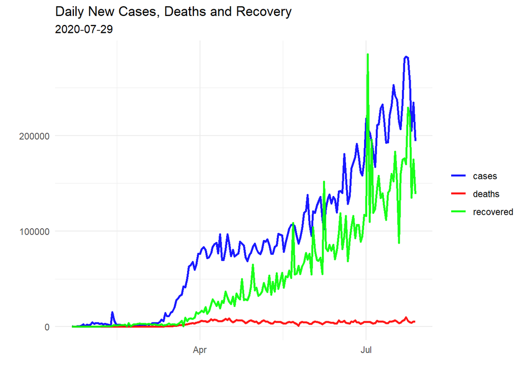

```r
data %>%
    group_by(date, data_type) %>%
    summarise(count = sum(value)) %>%
    ggplot()+
    aes(date, count, color = data_type)+
    geom_line(size = 1, alpha = 0.9)+
    scale_color_manual(values=c("blue", "red", "green"))+
    theme_minimal()+
    theme(legend.title = element_blank())+
    labs(x = "", y = "", title = "Daily New Cases, Deaths and Recovery", subtitle = today())
```

### Continent wise data

We will use “countrycode” package to assign the continent name to the countries in the dataset. We will make a separate column for continent

```r
countrydata = filter(data, location_type == 'country')
countrydata$continent = countrycode(sourcevar = countrydata[, "location"],
                               origin = "country.name",
                               destination = "continent")
head(countrydata)
```

```
##         date    location location_type location_code location_code_type
## 1 2020-01-22 Afghanistan       country            AF         iso_3166_2
## 2 2020-01-22 Afghanistan       country            AF         iso_3166_2
## 3 2020-01-22 Afghanistan       country            AF         iso_3166_2
## 4 2020-01-22     Albania       country            AL         iso_3166_2
## 5 2020-01-22     Albania       country            AL         iso_3166_2
## 6 2020-01-22     Albania       country            AL         iso_3166_2
##   data_type value      lat     long continent
## 1     cases     0 33.93911 67.70995      Asia
## 2 recovered     0 33.93911 67.70995      Asia
## 3    deaths     0 33.93911 67.70995      Asia
## 4 recovered     0 41.15330 20.16830    Europe
## 5     cases     0 41.15330 20.16830    Europe
## 6    deaths     0 41.15330 20.16830    Europe
```

```r
# Removing cruise ships data and assigning Kosovo to Europe
countrydata$continent[countrydata$location == "Kosovo"] = "Europe"
countrydata = countrydata[- grep("Diamond Princess", countrydata$location),]
countrydata = countrydata[- grep("MS Zaandam", countrydata$location),]
```

```r
# Cumulative Cases Continent wise
continent_df = countrydata %>%
    group_by(continent, data_type) %>%
    mutate(cumvalues = cumsum(value)) %>%
    select(date,continent, data_type, cumvalues)
```

[output not shown]

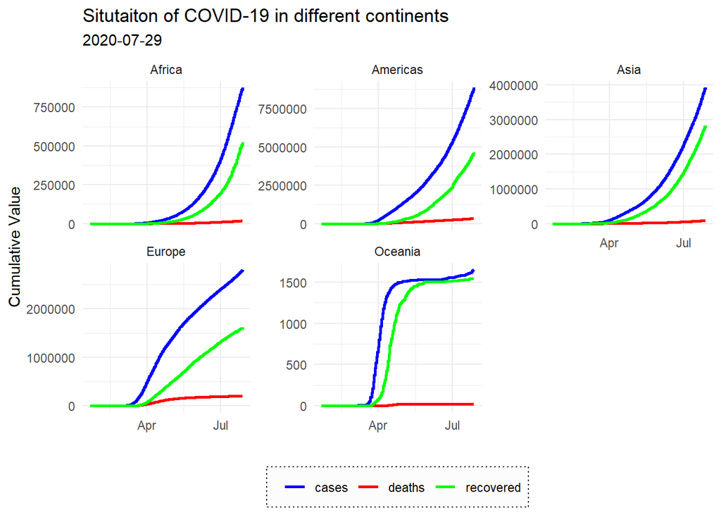

```r
# Plot
ggplot(continent_df)+
    aes(date, cumvalues, color = data_type)+
    geom_line(size = 1)+
    facet_wrap(~continent, scales = "free_y")+
    theme_minimal()+
    labs(x = "", y = "Cumulative Value", title = "Situtaiton of COVID-19 in different continents", subtitle = today())+
    scale_color_discrete(name="")+
    theme(legend.background = element_rect(fill="#fcfcfc", size=.5, linetype="dotted"), legend.position = "bottom", legend.title = element_blank()) +
    scale_color_manual(values=c("blue", "red", "green"))
```

### Country and province wise data

```r
df = data %>%
  group_by(location, data_type) %>%
  summarise(total = sum(value)) %>%
  pivot_wider(names_from =  data_type, values_from = total) %>%
  mutate(active = cases - ifelse(is.na(recovered), 0, recovered) - ifelse(is.na(deaths), 0, deaths)) %>%
  arrange(-cases) %>%
  ungroup() %>%
  mutate(location = if_else(location == "United Arab Emirates", "UAE", location)) %>%
  mutate(location = if_else(location == "Mainland China", "China", location)) %>%
  mutate(location = if_else(location == "North Macedonia", "N.Macedonia", location)) %>%
  mutate(location = trimws(location)) %>%
  mutate(location = factor(location, levels = location))
df %>% kable(digits = 2, format = "html", row.names = TRUE) %>%
  kable_styling(bootstrap_options = c("striped", "hover"),
                full_width = T,
                font_size = 15) %>%
   scroll_box(height = "300px")
```

|  | location | cases | deaths | recovered | active |
| --- | --- | --- | --- | --- | --- |
| 1 | US | 4351997 | 149256 | 1355363 | 2847378 |
| 2 | Brazil | 2483191 | 88539 | 1868749 | 525903 |
| 3 | India | 1483156 | 33425 | 952743 | 496988 |
| 4 | Russia | 822060 | 13483 | 611109 | 197468 |
| 5 | South Africa | 459761 | 7257 | 287313 | 165191 |
| 6 | Mexico | 402697 | 44876 | 308142 | 49679 |
| 7 | Peru | 389717 | 18418 | 276452 | 94847 |
| 8 | Chile | 349800 | 9240 | 322332 | 18228 |
| 9 | United Kingdom | 300658 | 45878 | 0 | 254780 |
| 10 | Iran | 296273 | 16147 | 257019 | 23107 |
| 11 | Spain | 280610 | 28436 | 150376 | 101798 |
| 12 | Pakistan | 275225 | 5865 | 242436 | 26924 |
| 13 | Saudi Arabia | 270831 | 2789 | 225624 | 42418 |
| 14 | Colombia | 267385 | 9074 | 136690 | 121621 |
| 15 | Italy | 246488 | 35123 | 198756 | 12609 |
| 16 | Bangladesh | 229185 | 3000 | 127414 | 98771 |
| 17 | Turkey | 227982 | 5645 | 211561 | 10776 |
| 18 | France | 209342 | 30109 | 71667 | 107566 |
| 19 | Germany | 207707 | 9131 | 190711 | 7865 |
| 20 | Argentina | 173355 | 3179 | 75083 | 95093 |
| 21 | Iraq | 115332 | 4535 | 81062 | 29735 |
| 22 | Qatar | 109880 | 167 | 106603 | 3110 |
| 23 | Indonesia | 102051 | 4901 | 60539 | 36611 |
| 24 | Egypt | 92947 | 4691 | 35959 | 52297 |
| 25 | Kazakhstan | 86192 | 793 | 56638 | 28761 |
| 26 | Philippines | 83673 | 1947 | 26617 | 55109 |
| 27 | Ecuador | 82279 | 5584 | 35283 | 41412 |
| 28 | Sweden | 79494 | 5702 | 0 | 73792 |
| 29 | Oman | 77904 | 402 | 58587 | 18915 |
| 30 | Bolivia | 72327 | 2720 | 21971 | 47636 |

[output cut: 237 more lines]

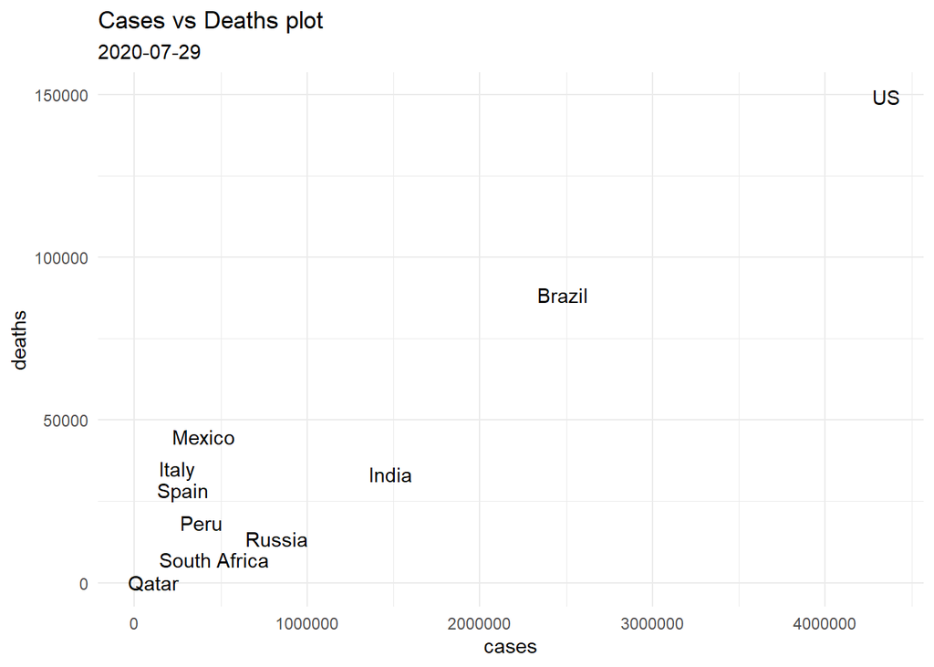

```r
df %>%
    filter(cases > 5000) %>%
    ggplot()+
    geom_text(aes(cases, deaths, label = location), check_overlap = T)+
    theme_minimal()+
    labs(title = "Cases vs Deaths plot", subtitle = today())
```

## Bibliography

1. CSSEGISandData. (2020). CSSEGISandData/COVID-19. https://github.com/CSSEGISandData/COVID-19 (Original work published 2020)
2. Krispin, R. (2020). RamiKrispin/coronavirus [R]. https://github.com/RamiKrispin/coronavirus (Original work published 2020)